# 4_ICA_actigraphy_36R

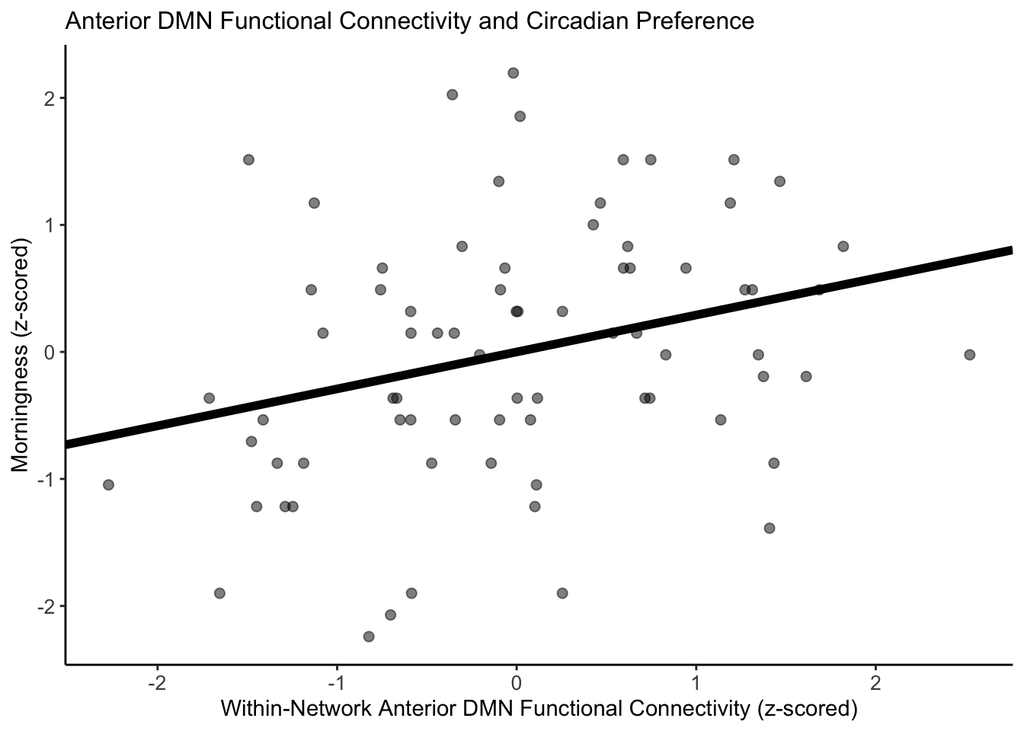

`r ggsave("aDMN_Z_36R_and_CMEP.png", m8_plot, width = 6, height =6)`

### mc correction

`r p_all <- c(m6p, m7p, m8p) # we have 6 effects tested against each other in 3 regressions. FDR is of those (discoveries) rejected null hypotheses, what's the expected value of those that are false (that are incorrect rejections of true null)? # uncorrected:0.4620 0.7080 0.5080 0.8170 0.0124 0.4144 p.adjust(p_all, method = "fdr", n = length(p_all))`

`## [1] 0.7620 0.8170 0.7620 0.8170 0.0744 0.7620`

`r # corrected: 0.7620 0.8170 0.7620 0.8170 0.0744 0.7620`

# hold controlling for cdi, siq, and asq?

`r m9 <- lm(cmep_total_act_z ~ aDMN_Z_36R_z + asq_total_act + cdi_total_with_actigraphy + siq_total_with_actigraphy , data = dem_plus_act_clin_netcorrcmep_cent) summary(gvlma(m9))`

`## ## Call: ## lm(formula = cmep_total_act_z ~ aDMN_Z_36R_z + asq_total_act + ## cdi_total_with_actigraphy + siq_total_with_actigraphy, data = dem_plus_act_clin_netcorrcmep_cent) ## ## Residuals: ## Min 1Q Median 3Q Max ## -1.53464 -0.65841 -0.06464 0.53281 1.91054 ## ## Coefficients: ## Estimate Std. Error t value Pr(>|t|) ## (Intercept) 1.231288 0.386100 3.189 0.00224 ** ## aDMN_Z_36R_z 0.107709 0.107845 0.999 0.32180 ## asq_total_act -0.005327 0.003270 -1.629 0.10839 ## cdi_total_with_actigraphy -0.084674 0.043446 -1.949 0.05583 . ## siq_total_with_actigraphy -0.011724 0.007460 -1.572 0.12111 ## --- ## Signif. codes: 0 '***' 0.001 '**' 0.01 '*' 0.05 '.' 0.1 ' ' 1 ## ## Residual standard error: 0.8295 on 62 degrees of freedom ## (8 observations deleted due to missingness) ## Multiple R-squared: 0.3568, Adjusted R-squared: 0.3153 ## F-statistic: 8.598 on 4 and 62 DF, p-value: 0.00001381 ## ## ## ASSESSMENT OF THE LINEAR MODEL ASSUMPTIONS ## USING THE GLOBAL TEST ON 4 DEGREES-OF-FREEDOM: ## Level of Significance = 0.05 ## ## Call: ## gvlma(x = m9) ## ## Value p-value Decision ## Global Stat 3.27661 0.5126 Assumptions acceptable. ## Skewness 0.82769 0.3629 Assumptions acceptable. ## Kurtosis 0.54681 0.4596 Assumptions acceptable. ## Link Function 0.03393 0.8538 Assumptions acceptable. ## Heteroscedasticity 1.86817 0.1717 Assumptions acceptable.`

`r summary(m9)`

`## ## Call: ## lm(formula = cmep_total_act_z ~ aDMN_Z_36R_z + asq_total_act + ## cdi_total_with_actigraphy + siq_total_with_actigraphy, data = dem_plus_act_clin_netcorrcmep_cent) ## ## Residuals: ## Min 1Q Median 3Q Max ## -1.53464 -0.65841 -0.06464 0.53281 1.91054 ## ## Coefficients: ## Estimate Std. Error t value Pr(>|t|) ## (Intercept) 1.231288 0.386100 3.189 0.00224 ** ## aDMN_Z_36R_z 0.107709 0.107845 0.999 0.32180 ## asq_total_act -0.005327 0.003270 -1.629 0.10839 ## cdi_total_with_actigraphy -0.084674 0.043446 -1.949 0.05583 . ## siq_total_with_actigraphy -0.011724 0.007460 -1.572 0.12111 ## --- ## Signif. codes: 0 '***' 0.001 '**' 0.01 '*' 0.05 '.' 0.1 ' ' 1 ## ## Residual standard error: 0.8295 on 62 degrees of freedom ## (8 observations deleted due to missingness) ## Multiple R-squared: 0.3568, Adjusted R-squared: 0.3153 ## F-statistic: 8.598 on 4 and 62 DF, p-value: 0.00001381`

`r vif(m9)`

`## aDMN_Z_36R_z asq_total_act cdi_total_with_actigraphy ## 1.127710 1.823062 1.887403 ## siq_total_with_actigraphy ## 1.320533`

`r m9 <- lm(cmep_total_act_z ~ asq_total_act + cdi_total_with_actigraphy, data = dem_plus_act_clin_netcorrcmep_cent) vif(m9)`

`## asq_total_act cdi_total_with_actigraphy ## 1.710448 1.710448`

`r summary(m9)`

`## ## Call: ## lm(formula = cmep_total_act_z ~ asq_total_act + cdi_total_with_actigraphy, ## data = dem_plus_act_clin_netcorrcmep_cent) ## ## Residuals: ## Min 1Q Median 3Q Max ## -1.73952 -0.66663 0.03183 0.49937 2.29281 ## ## Coefficients: ## Estimate Std. Error t value Pr(>|t|) ## (Intercept) 1.046748 0.399180 2.622 0.0107 * ## asq_total_act -0.004508 0.003296 -1.368 0.1758 ## cdi_total_with_actigraphy -0.100817 0.041259 -2.444 0.0171 * ## --- ## Signif. codes: 0 '***' 0.001 '**' 0.01 '*' 0.05 '.' 0.1 ' ' 1 ## ## Residual standard error: 0.9002 on 70 degrees of freedom ## (2 observations deleted due to missingness) ## Multiple R-squared: 0.2289, Adjusted R-squared: 0.2069 ## F-statistic: 10.39 on 2 and 70 DF, p-value: 0.0001119`

`r plot_model(m9)`

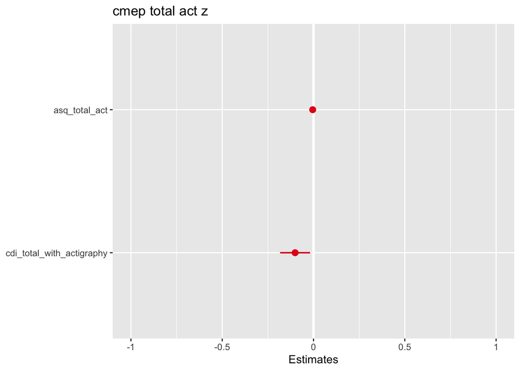

> does the interval really not matter? We replicate this analysis using only those who completed EMA, Act, and Scan within 7 days of each other in our “simultaneous script”

# 11 obj sleep duration

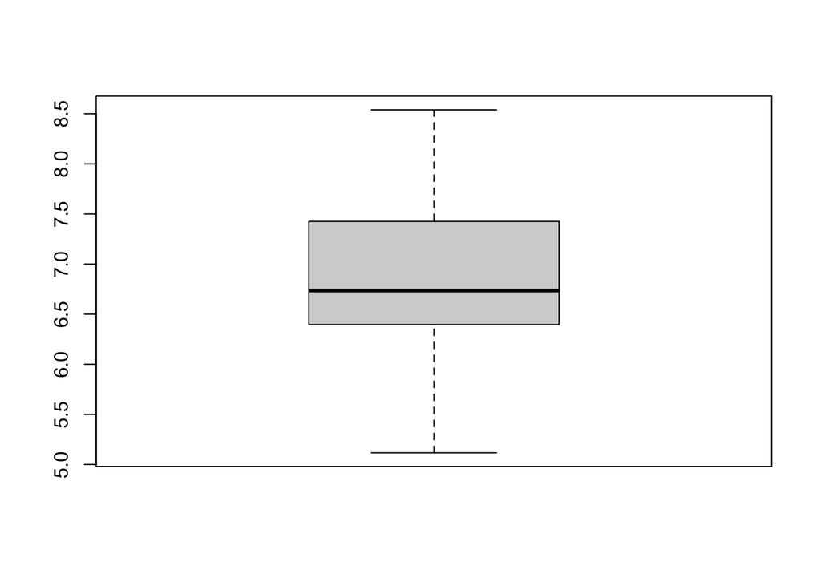

```r
# sleep efficiency outliers
OutVals = boxplot(dem_plus_act_clin_netcorr$sleep_time_hrs_mean)$out #
```

## 11.1 centering based on this sample

I standardized tanner stage, age at tanner assessment, and bmi within each sex

```r
dem_plus_act_clin_netcorr_cent <-
  dem_plus_act_clin_netcorr %>%
  mutate(
    Sex = factor(Sex),
    COVID_AHC_ACT = factor(COVID_AHC_ACT),
    eff_perc_mean_z = scale(eff_perc_mean),
    sleep_time_hrs_mean_z = scale(sleep_time_hrs_mean),
    household_income_act_z = scale(Household_Income_ACT),
    sumsev_type_z = scale(sumsev_type),
    asq_total_act_z = scale(asq_total_act),
    cmep_total_act_z = scale(cmep_total_act),
    admn_lecn_act_z = scale(admn_lecn_act),
    admn_recn_act_z = scale(admn_recn_act),
    pdmn_lecn_act_z = scale(pdmn_lecn_act),
    pdmn_recn_act_z = scale(pdmn_recn_act),
    pDMN_Z_36R_z = scale(pDMN_Z_36R),
    aDMN_Z_36R_z = scale(aDMN_Z_36R),
    Noise_brainstem_Z_36R_z = scale(Noise_brainstem_Z_36R)
    ) %>%
  group_by(Sex) %>%
  mutate(
    tanner_average_for_act_z = scale(tanner_average_for_act), # standardize within each sex
    tanner_adrenal_act_z = scale(tanner_adrenal_act),
    tanner_gonadal_act_z = scale(tanner_gonadal_act),
    bmi_at_act_z = scale(BMI_ACT),
    tanner_age_for_act_z = scale(tanner_age_for_act)
  ) %>%
  ungroup()
```